# Quantifying model fit

Edneide Ramalho

03 Fevereiro, 2022

# 1 Coefficient of determination

```r
library(tidyverse)
library(rrcov)
```

```r
data(fish)
fish <- fish
```

- “r-squared” or “R-squared”.

> It’s the proportion of the variance in the response variable that is predictable from the explanatory variable.
- $r^2$ = 1 -> means a perfect fit
- $r^2$ = 0 -> means the worst possible fit

## 1.1 `summary()`

```r
bream <- fish %>%
  dplyr::filter(Species == 1) %>%
  dplyr::select(Weight, Length1)

names(bream) <- c("mass_g", "length_cm")
```

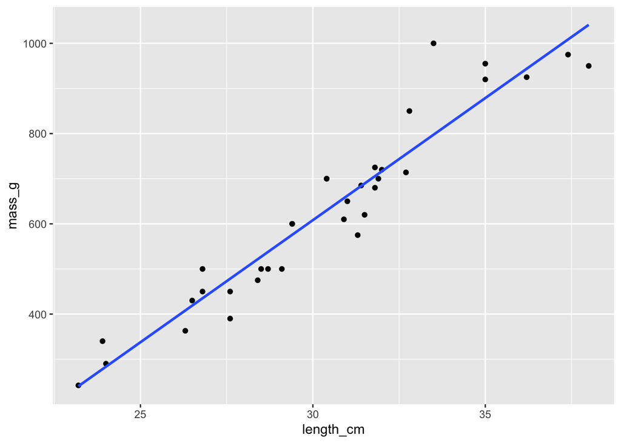

```r
ggplot(bream, aes(length_cm, mass_g)) +
  geom_point() +
  geom_smooth(method = "lm", se = FALSE)
```

```r
mdl_bream <- lm(mass_g ~ length_cm, data = bream)
summary(mdl_bream)
```

```
##
## Call:
## lm(formula = mass_g ~ length_cm, data = bream)
##
## Residuals:
##      Min       1Q   Median       3Q      Max
## -103.516  -39.659   -4.954   24.288  202.447
##
## Coefficients:
##              Estimate Std. Error t value Pr(>|t|)
## (Intercept) -1015.050     91.184  -11.13 1.54e-12 ***
## length_cm      54.108      2.986   18.12  < 2e-16 ***
## ---
## Signif. codes:  0 '***' 0.001 '**' 0.01 '*' 0.05 '.' 0.1 ' ' 1
##
## Residual standard error: 62.51 on 32 degrees of freedom
##   (1 observation deleted due to missingness)
## Multiple R-squared:  0.9112, Adjusted R-squared:  0.9084
## F-statistic: 328.4 on 1 and 32 DF,  p-value: < 2.2e-16
```

- Another interesting function to get the model’s metrics is `glance()` from `broom` package.

## 1.2 `glance()`

```r
library(broom)
library(dplyr)
mdl_bream %>%
  glance()
```

```
## # A tibble: 1 x 12
##   r.squared adj.r.squared sigma statistic  p.value    df logLik   AIC   BIC
##       <dbl>         <dbl> <dbl>     <dbl>    <dbl> <dbl>  <dbl> <dbl> <dbl>
## 1     0.911         0.908  62.5      328. 2.18e-18     1  -188.  382.  386.
## # … with 3 more variables: deviance <dbl>, df.residual <int>, nobs <int>
```

- r-squared

```r
mdl_bream %>%
  glance() %>%
  pull(r.squared) %>%
  round(2)
```

```
## [1] 0.91
```

-> r-squared is just correlation between the variables, squared.

```r
na.omit(bream) %>%
  dplyr::summarize(
    coeff_determination = cor(length_cm, mass_g) ^ 2
  )
```

```
##   coeff_determination
## 1           0.9112186
```

## 1.3 Residual standard error (RSE)

> Difference between a prediction and an observed response.

$$\text{RSE} = \sqrt{\dfrac{\sum_{i=1}^{n}(Y_i - \hat{Y_i})^2}{\text{df}}}$$

- The `summary()` function shows the RSE, called Residual standard error:

*Residual standard error: 62.51 on 32 degrees of freedom*

- In the `glance()` function, RSE is named `sigma`

```r
mdl_bream %>%
  glance() %>%
  pull(sigma)
```

```
## [1] 62.51483
```

- Interpreting RSE

> **The difference between predicted masses and observed bream masses is typically about 62.5g.**

## 1.4 Root-mean-square error (RMSE)

- It is used for comparison between models.
- It is similar to RSE, but for RMSE we dived the sum of squared residuals by the number of observations.

$$\text{RMSE} = \sqrt{\dfrac{\sum \text{residuals}^2}{n}}$$

or

$$\text{RMSE} = \sqrt{\dfrac{1}{n}\sum_{i=1}^n (y_i - \hat{y_i})^2}$$

## 1.5 Exercises

### 1.5.1 Coefficient of determination

The coefficient of determination is a measure of how well the linear regression line fits the observed values. For simple linear regression, it is equal to the square of the correlation between the explanatory and response variables.

Here, you’ll take another look at the second stage of the advertising pipeline: modeling the click response to impressions. Two models are available: `mdl_click_vs_impression_orig` models `n_clicks` versus `n_impressions`. `mdl_click_vs_impression_trans` is the transformed model you saw in Chapter 2. It models `n_clicks ^ 0.25` versus `n_impressions ^ 0.25`.

broom is loaded.

- Print a summary of `mdl_click_vs_impression_orig`. Do the same for `mdl_click_vs_impression_trans`.

```r
# 0. Packages
library(broom)
library(dplyr)
library(readr)
```

```r
ad_conversion <- read_csv("ad_conversion.csv")
glimpse(ad_conversion)
```

```
## Rows: 936
## Columns: 3
## $ spent_usd     <dbl> 1.43, 1.82, 1.25, 1.29, 4.77, 1.27, 1.50, 3.16, 10.28, 0…
## $ n_impressions <dbl> 7350, 17861, 4259, 4133, 15615, 10951, 2355, 9502, 14669…
## $ n_clicks      <dbl> 1, 2, 1, 1, 3, 1, 1, 3, 7, 1, 1, 4, 2, 2, 2, 2, 4, 2, 7,…
```

- Original model:

```r
mdl_click_vs_impression_orig <- lm(n_clicks ~ n_impressions, data = ad_conversion)
summary(mdl_click_vs_impression_orig)
```

```
##
## Call:
## lm(formula = n_clicks ~ n_impressions, data = ad_conversion)
##
## Residuals:
##      Min       1Q   Median       3Q      Max
## -186.099   -5.392   -1.422    2.070  119.876
##
## Coefficients:
##                Estimate Std. Error t value Pr(>|t|)
## (Intercept)   1.683e+00  7.888e-01   2.133   0.0331 *
## n_impressions 1.718e-04  1.960e-06  87.654   <2e-16 ***
## ---
## Signif. codes:  0 '***' 0.001 '**' 0.01 '*' 0.05 '.' 0.1 ' ' 1
##
## Residual standard error: 19.91 on 934 degrees of freedom
## Multiple R-squared:  0.8916, Adjusted R-squared:  0.8915
## F-statistic:  7683 on 1 and 934 DF,  p-value: < 2.2e-16
```

- Transformed model:

```r
mdl_click_vs_impression_trans <- lm(I(n_clicks^0.25) ~ I(n_impressions^0.25), data = ad_conversion)
summary(mdl_click_vs_impression_trans)
```

```
##
## Call:
## lm(formula = I(n_clicks^0.25) ~ I(n_impressions^0.25), data = ad_conversion)
##
## Residuals:
##      Min       1Q   Median       3Q      Max
## -0.57061 -0.13229  0.00582  0.14494  0.46888
##
## Coefficients:
##                        Estimate Std. Error t value Pr(>|t|)
## (Intercept)           0.0717479  0.0172019   4.171 3.32e-05 ***
## I(n_impressions^0.25) 0.1115330  0.0008844 126.108  < 2e-16 ***
## ---
## Signif. codes:  0 '***' 0.001 '**' 0.01 '*' 0.05 '.' 0.1 ' ' 1
##
## Residual standard error: 0.1969 on 934 degrees of freedom
## Multiple R-squared:  0.9445, Adjusted R-squared:  0.9445
## F-statistic: 1.59e+04 on 1 and 934 DF,  p-value: < 2.2e-16
```

- Get the coefficient of determination for mdl_click_vs_impression_orig by glancing at the model, then pulling the r.squared value.
- Do the same for mdl_click_vs_impression_trans.

```r
# Get coeff of determination for mdl_click_vs_impression_orig
mdl_click_vs_impression_orig %>%
  # Get the model-level details
  glance() %>%
  # Pull out r.squared
  pull(r.squared)
```

```
## [1] 0.8916135
```

```r
# Do the same for the transformed model
mdl_click_vs_impression_trans %>%
  glance() %>%
  pull(r.squared)
```

```
## [1] 0.9445273
```

- The number of impressions explain 89% of the number of clicks variability for the original model.
- The transformed model has a higher coefficient of determination that the original model, suggesting that it gives a better fit to the data.

### 1.5.2 Residual standard error

Residual standard error (RSE) is a measure of the typical size of the residuals. Equivalently, it’s a measure of how badly wrong you can expect predictions to be. Smaller numbers are better, with zero being a perfect fit to the data.

Again, you’ll look at the models from the advertising pipeline, `mdl_click_vs_impression_orig` and `mdl_click_vs_impression_trans`. broom is loaded.

Get the residual standard error for `mdl_click_vs_impression_orig` by glancing at the model, then pulling the sigma value. Do the same for `mdl_click_vs_impression_trans`.

```r
mdl_click_vs_impression_orig %>%
  glance() %>%
  pull(sigma)
```

```
## [1] 19.90584
```

- The typical difference between observed number of clicks and predicted number of clicks is `20`.

```r
mdl_click_vs_impression_trans %>%
  glance() %>%
  pull(sigma)
```

```
## [1] 0.1969064
```

- According to the RSE, the transformed model gives more accurate predictions.

# 2 Visualizing model fit

## 2.1 Residual properties

- Residual are normally distributed
- The mean of the residuals is zero
- We use some diagnostic plots to check the residuals:
  - Residual vs. fitted values
  - Q-Q plot
  - Scale-Location

```r
library(ggplot2)
library(ggfortify)

autoplot(model_object, which = ???)
```

- Values for `which`
  1. residual vs. fitted values
  2. Q-Q plot
  3. scale-location

```r
library(rrcov)
data(fish)

perch <- fish %>%
  dplyr::filter(Species == 7) %>%
  dplyr::select(Weight, Length1)
names(perch) <- c("mass_g", "length_cm")
mdl_perch <- lm(mass_g ~ I(length_cm^3), data = perch)
mdl_perch
```

```
##
## Call:
## lm(formula = mass_g ~ I(length_cm^3), data = perch)
##
## Coefficients:
##    (Intercept)  I(length_cm^3)
##        -0.1175          0.0168
```

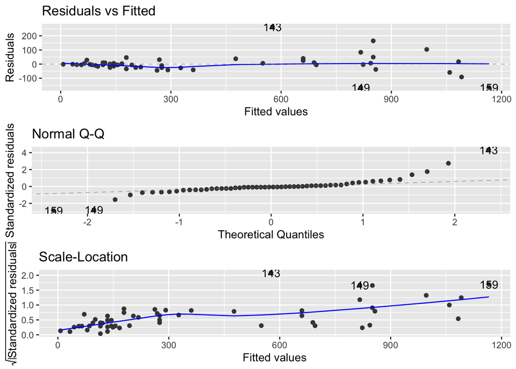

```r
library(ggplot2)
library(ggfortify)
autoplot(
  mdl_perch,
  which = 1:3,
  nrow = 3,
  ncol = 1
)
```

## 2.2 Exercises

### 2.2.1 Let’s take a look at some diagnostic plots for the number of clicks model.

- **Residual vs Fitted**

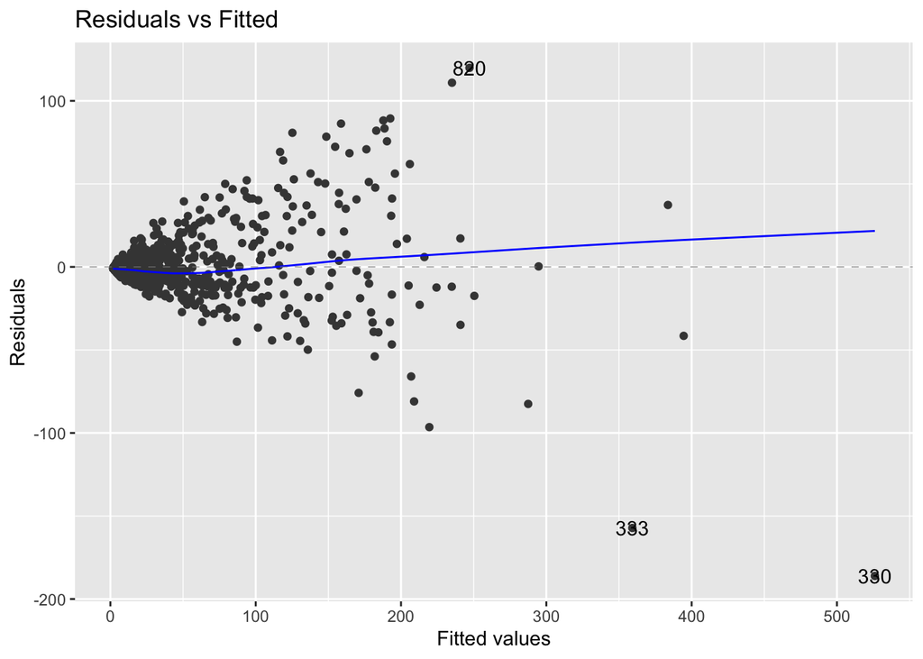

```r
# Original model
autoplot(
  mdl_click_vs_impression_orig,
  which = 1,
  nrow = 1,
  ncol = 1
)
```

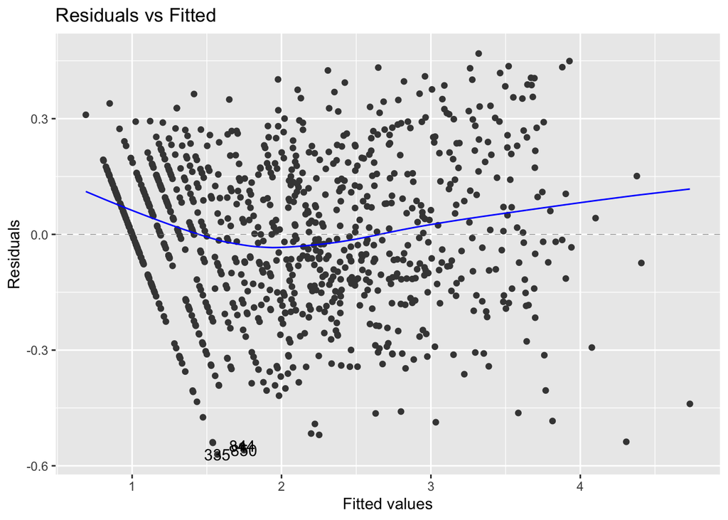

```r
# Transformed model
autoplot(
  mdl_click_vs_impression_trans,
  which = 1,
  nrow = 1,
  ncol = 1
)
```

- In a good model, the residuals should have a trend line close to zero. It is the case in the transformed model.
- **Q-Q plot**

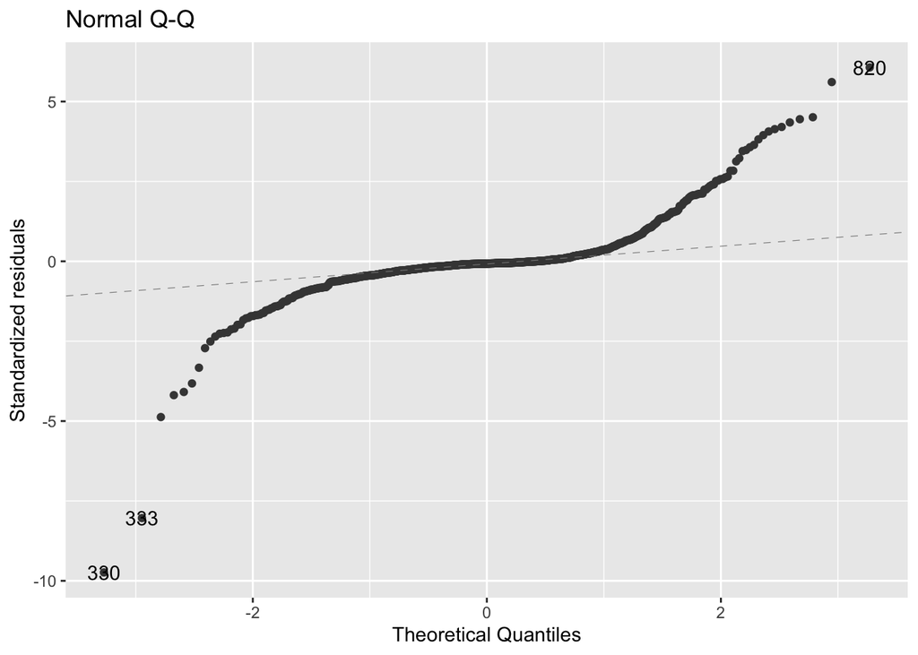

```r
# Original model
autoplot(
  mdl_click_vs_impression_orig,
  which = 2,
  nrow = 1,
  ncol = 1
)
```

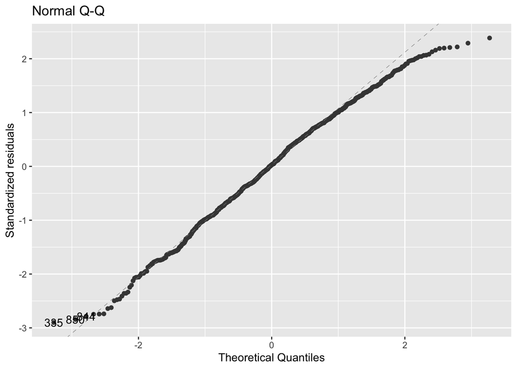

```r
# Transformed model
autoplot(
  mdl_click_vs_impression_trans,
  which = 2,
  nrow = 1,
  ncol = 1
)
```

- If the residuals from the model are normally distributed, then the points will track the line on the Q-Q plot. In this case, neither model is perfect, but the transformed model is closer.
- **Scale-Location**

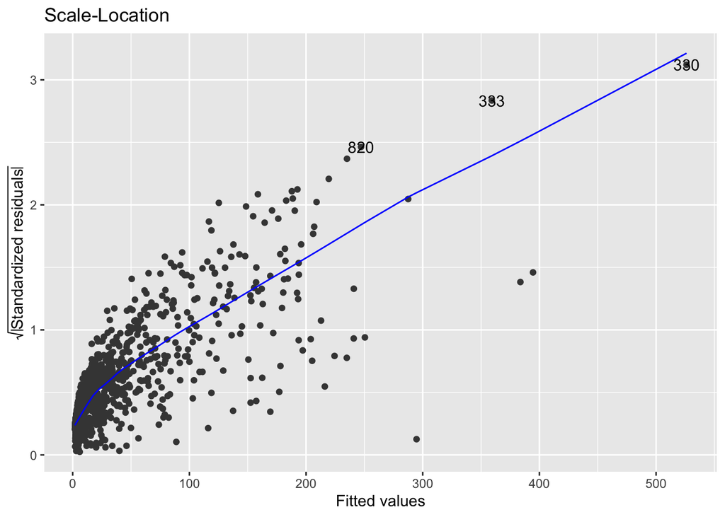

```r
# Original model
autoplot(
  mdl_click_vs_impression_orig,
  which = 3,
  nrow = 1,
  ncol = 1
)
```

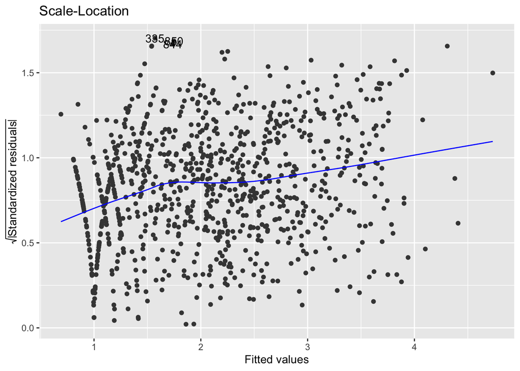

```r
# Transformed model
autoplot(
  mdl_click_vs_impression_trans,
  which = 3,
  nrow = 1,
  ncol = 1
)
```

- The size of the standardized residuals is more consistent in the transformed model compared to the original model, indicating that the transformed model is a better fit for the data.
- In a good model, the size of the residuals shouldn’t change much as the fitted values change.

### 2.2.2 **Drawing diagnostic plots**

It’s time for you to draw these diagnostic plots yourself. Let’s go back to the Taiwan real estate dataset and the model of house prices versus number of convenience stores.

Recall that `autoplot()` lets you specify which diagnostic plots you are interested in.

- `1` residuals vs. fitted values
- `2` Q-Q plot
- `3` scale-location

`mdl_price_vs_conv` is available, and `ggplot2` and `ggfortify` are loaded.

- Plot the three diagnostic plots (numbered `1` to `3`) for `mdl_price_vs_conv`. Use a layout of three rows and one column.

```r
library(fst) # to read fst format
library(tidyverse)

# data
taiwan_real_estate <- read_fst(
  "taiwan_real_estate.fst",
  columns = NULL,
  from = 1,
  to = NULL,
  as.data.table = FALSE,
  old_format = FALSE
)
mdl_price_vs_conv <- lm(formula = price_twd_msq ~ n_convenience, data = taiwan_real_estate)
```

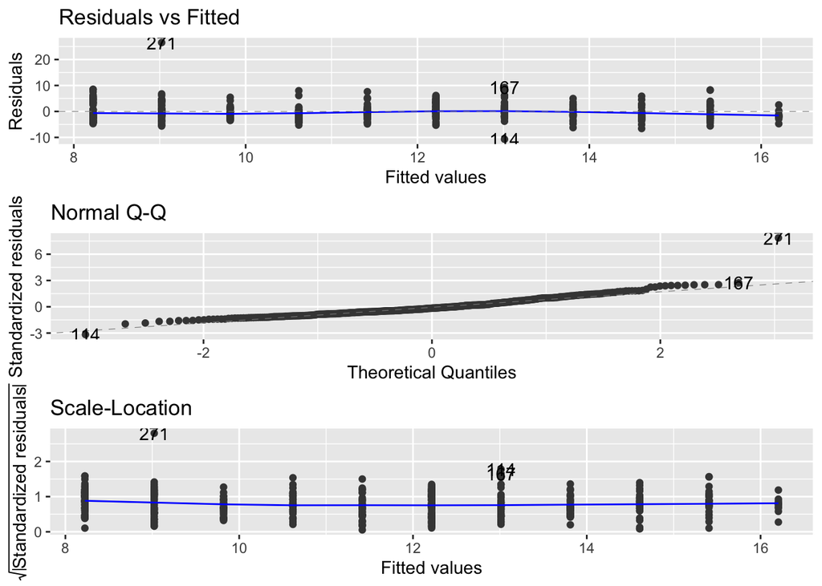

```r
# Plot the three diagnostics for mdl_price_vs_conv
autoplot(mdl_price_vs_conv,
         which = 1:3,
         nrow = 3,
         ncol = 1)
```

# 3 Outliers, leverage, and influence

```r
glimpse(fish)
```

```
## Rows: 159
## Columns: 7
## $ Weight  <dbl> 242, 290, 340, 363, 430, 450, 500, 390, 450, 500, 475, 500, 50…
## $ Length1 <dbl> 23.2, 24.0, 23.9, 26.3, 26.5, 26.8, 26.8, 27.6, 27.6, 28.5, 28…
## $ Length2 <dbl> 25.4, 26.3, 26.5, 29.0, 29.0, 29.7, 29.7, 30.0, 30.0, 30.7, 31…
## $ Length3 <dbl> 30.0, 31.2, 31.1, 33.5, 34.0, 34.7, 34.5, 35.0, 35.1, 36.2, 36…
## $ Height  <dbl> 38.4, 40.0, 39.8, 38.0, 36.6, 39.2, 41.1, 36.2, 39.9, 39.3, 39…
## $ Width   <dbl> 13.4, 13.8, 15.1, 13.3, 15.1, 14.2, 15.3, 13.4, 13.8, 13.7, 14…
## $ Species <int> 1, 1, 1, 1, 1, 1, 1, 1, 1, 1, 1, 1, 1, 1, 1, 1, 1, 1, 1, 1, 1,…
```

```r
roach <- fish %>%
  dplyr::filter(Species == 3) %>%
  dplyr::select(Weight, Length1) %>%
  dplyr::rename(mass_g = Weight, length_cm = Length1)

glimpse(roach)
```

```
## Rows: 20
## Columns: 2
## $ mass_g    <dbl> 40, 69, 78, 87, 120, 0, 110, 120, 150, 145, 160, 140, 160, 1…
## $ length_cm <dbl> 12.9, 16.5, 17.5, 18.2, 18.6, 19.0, 19.1, 19.4, 20.4, 20.5, …
```

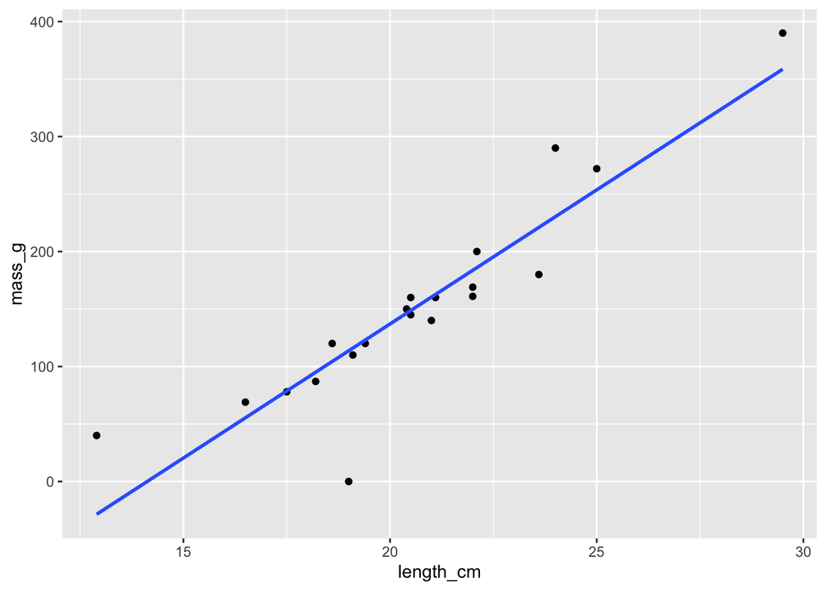

```r
ggplot(roach, aes(length_cm, mass_g)) +
  geom_point() +
  geom_smooth(method = "lm", se = FALSE)
```